# a Presentation on quakes APP built using Shiny

Tanmoy Rath

27 August 2019

## App Overview

Shiny App Link: **https://tanmoy.shinyapps.io/quakes/**  
ui.R/server.R Link: **https://github.com/Tanmoy-Rath/developingdataproducts**

This Presentation is about an RStudio Shiny application, that plots various scatterplots of the quakes dataset, and in turn shows/explores the relationship among the different columns of the quakes data-frame.

The app contains 4 widgets (in the sidebar panel) to take inputs from user and plot the desired ggplot2 scatter-plot.

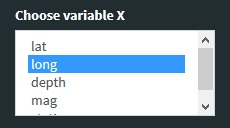

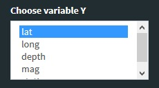

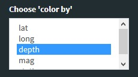

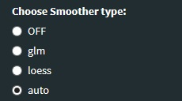

The widgets themselves are self-explanatory, however you are further encouraged to visit the app’s in-built documentation for more details.

## quakes dataset & High-correlation

```r
library(ggplot2); str(quakes)
```

```
## 'data.frame':    1000 obs. of  5 variables:
##  $ lat     : num  -20.4 -20.6 -26 -18 -20.4 ...
##  $ long    : num  182 181 184 182 182 ...
##  $ depth   : int  562 650 42 626 649 195 82 194 211 622 ...
##  $ mag     : num  4.8 4.2 5.4 4.1 4 4 4.8 4.4 4.7 4.3 ...
##  $ stations: int  41 15 43 19 11 12 43 15 35 19 ...
```

The app shows that there is a high positive correlation among **mag**(magnitude of earthquakes) and **stations**(no. of stations reporting the event)

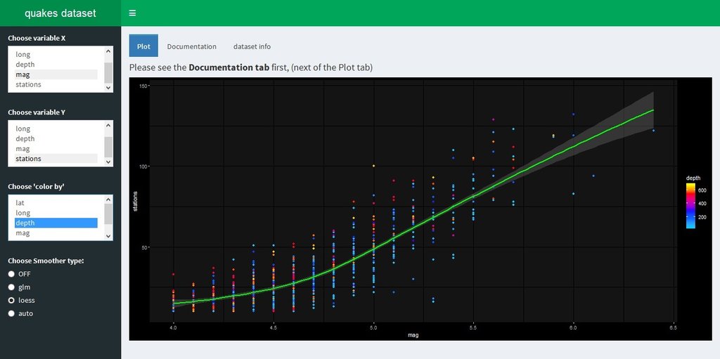

## Correlation calculation with p-values

mag-stations correlation(=0.85) is highest. Correlations with insignificant p-values(> 0.05) are crossed.

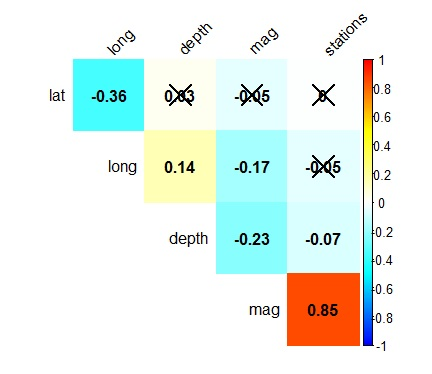

```r
library(corrplot); library(Hmisc)
res <- rcorr(as.matrix(quakes))
col <- colorRampPalette(c("#0000FF", "#00FFFF", "#FFFFFF", "#FFFF00", "#FF0000"))
corrplot(res$r, method="color", addCoef.col = "black", tl.col="black", diag=FALSE, p.mat = res$P,
         sig.level = 0.05, type="upper", col=col(256), tl.srt=45)
```

## Insights revealed by color variable

In the lat-long scatter-plot, colouring by depth, clearly separates **areas of high & low depth** (high = yellow, low = blue). Areas of low depth (blue) are extremely dangerous, since the focus/source/origin of the earthquake is much closer to earth surface.

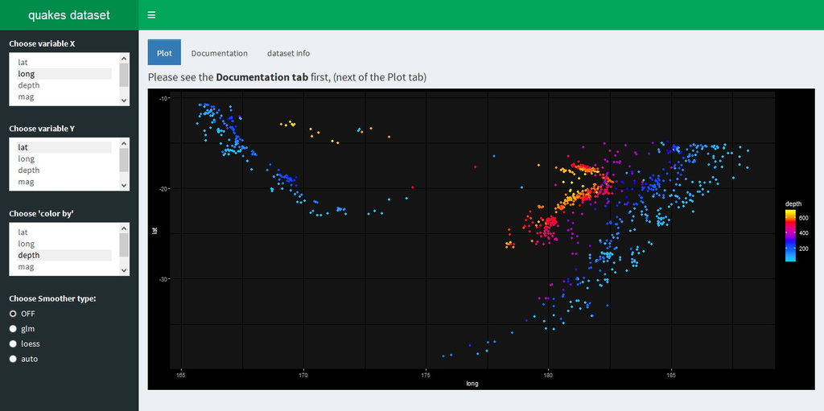